# Time dependent AUC with survival data _ correct2

Hwang Seong-Yun

2022 4 15

# Loading packages

```r
library(survival)
library(timeROC)
library(timereg)
library(ggplot2)
library(reshape)
library(plyr)
library(tidyverse)
library(coxed)
library(gridExtra)
```

# Generating simulation data from Cox regression

## Background

- reference 1 : https://doi.org/10.5351/KJAS.2018.31.6.761
- reference 2 : https://doi.org/10.1017/psrm.2018.19
- $h(t|x)=h_{0}(t)exp(f(x))$
- $H(t|x)=\int_{0}^{t} h(s|x)ds= \int_{0}^{t} h_{0}(s)exp(f(x))ds=H_{0}(t)exp(f(x))$
- $h(t|x)=\frac {f(t|x)}{S(t|x)}= -\frac {d}{dt} log[S(t|x)]$
- $log[S(t|x)]= -\int_{0}^{t} h(s|x)ds= -H(t|x)= -H_{0}(t)exp(f(x))$
- $S(t|x)=exp[-H_{0}(t)exp(f(x))]$
- In general,…
- $F(t|x)=1-exp[-H_{0}(t) exp(f(x))]$
- -> $F^{-1}(t|x)=H_{0}^{-1}[-log(1-t) exp(-f(x))]$
- By Inverse Transform Sampling, suppose that $U_{1}, U_{2} \overset{i.i.d}{\sim}\ U(0,1)$, then we can generate real survival time $Y$ from Cox Proportional Hazard Model using this equation.
- $Y=H_{Y0}^{-1}[-log(U_{1})exp(-f(x))]$
- And by assuming non-informative censoring, we can generate censoring time $C$ like this equation. (Set $Y$ and $C$ are independent each other.)
- $C=H_{C0}^{-1}[-log(U_{2})]$
- And set censoring indicator $\delta=I(Y \leq C)$ and observed survival time $T=min(Y,C)$
- $H_{Y0}(t|x)$ : Basis cumulative hazard function of real survival time $Y$
- $H_{C0}(t)$ : Basis cumulative hazard function of censoring time $C$
- When parametric basis distribution of real survival time $Y$ and censoring time $C$ are Exponential distribution and independent each other, then ~
- $f_{0}(t)=\lambda e^{-\lambda t}, t>0$ -> $S_{0}(t)=e^{-\lambda t}$ -> $h_{0}(t)=\lambda$
- $\therefore Y=-\frac{1}{\lambda_{1}} log(U_{1}) exp(-f(x))$, $C=-\frac{1}{\lambda_{2}} log(U_{2})$

# Generating simulation data

## Assume linear relationship

```r
# Assume parametric basis distribution is Exponential distribution...
lambda1 <- 0.1 # parameter for generate Y
lambda2 <- 0.05 # parameter for generate C
beta1 <- 3 # true coefficients
Y <- c() # real survival time
C <- c() # censoring time
t <- c() # observed survival time
censor <- c() # censoring indicator
X <- c() # explanatory variable
U1 <- c() # random variable from U(0,1) for generate Y
U2 <- c() # random variable from U(0,1) for generate C
X2 <- c() # X^2

for (i in 1:1000) {
  U1[i] <- runif(1)
  U2[i] <- runif(1)
  # X[i] <- runif(1,min=0,max=10)
  X[i] <- rnorm(1,mean=0,sd=1)
  X2[i] <- X[i]^2
  Y[i] <- -(1/lambda1)*log(U1[i])*exp(-beta1*X[i])
  C[i] <- -(1/lambda2)*log(U2[i])
  t[i] <- min(Y[i],C[i])
  censor[i] <- ifelse(Y[i]<=C[i],1,0)
}

mean(1-censor) # censoring rate
```

```
## [1] 0.417
```

```r
dt1 <- data.frame(X=X, X2=X2, Y=Y, C=C, time=t, censor=censor)
head(dt1,20)
```

```
##              X          X2            Y          C        time censor
## 1   0.03767127 0.001419125  10.88516782  1.3679194  1.36791944      0
## 2   0.63360600 0.401456559   2.95685549  5.3942959  2.95685549      1
## 3   0.37907296 0.143696308   1.70343122 43.0040823  1.70343122      1
## 4  -0.67526958 0.455989012  54.75617153 48.5590497 48.55904968      0
## 5  -0.85586814 0.732510267 107.48780297  8.6827611  8.68276107      0
## 6  -0.53171226 0.282717929  26.48116968 35.4786597 26.48116968      1
## 7  -0.20784116 0.043197947   6.39680126 44.7593014  6.39680126      1
## 8  -0.54646562 0.298624675  28.65070785 17.0494772 17.04947720      0
## 9   1.76845670 3.127439101   0.02145822  6.9697828  0.02145822      1
## 10  0.11356171 0.012896262  24.68074612 18.1353200 18.13532003      0
## 11  0.88338080 0.780361644   1.24667347  0.5956613  0.59566131      0
## 12  1.06207859 1.128010939   0.11452481 16.1239361  0.11452481      1
## 13  1.55325981 2.412616023   0.07948566 25.7748349  0.07948566      1
## 14 -0.67292564 0.452828915   6.52702460 49.4286001  6.52702460      1
## 15 -0.15055083 0.022665552  27.25575704  1.1096645  1.10966448      0
## 16 -0.27348936 0.074796430   6.27767110  8.7141998  6.27767110      1
## 17 -0.96870125 0.938382105 278.06426976  6.2276183  6.22761834      0
## 18 -1.19476178 1.427455719 134.79780068 73.8462939 73.84629391      0
## 19  0.30731135 0.094440266  10.49767765 17.2990158 10.49767765      1
## 20  0.09555385 0.009130538   2.54454433  0.6137531  0.61375307      0
```

```r
# dt1[c(order(dt1$time)),]$censor
```

### Time dependent AUC

### True model

- $h(t|x)=h _{0} (t)exp[f(x)]$
- $f(x)=\beta_{1} x$
- True coefficients : $\beta_{1}=3$

### Set linear model

- $h(t|x)=h _{0} (t)exp[f(x)]$
- $f(x)=\beta_{1}x$

```r
cox.lin.dt1 <- coxph(Surv(time,censor) ~ X, data=dt1)
summary(cox.lin.dt1)
```

```
## Call:
## coxph(formula = Surv(time, censor) ~ X, data = dt1)
##
##   n= 1000, number of events= 583
##
##       coef exp(coef) se(coef)     z Pr(>|z|)
## X  2.98476  19.78169  0.09645 30.95   <2e-16 ***
## ---
## Signif. codes:  0 '***' 0.001 '**' 0.01 '*' 0.05 '.' 0.1 ' ' 1
##
##   exp(coef) exp(-coef) lower .95 upper .95
## X     19.78    0.05055     16.37      23.9
##
## Concordance= 0.895  (se = 0.006 )
## Likelihood ratio test= 1477  on 1 df,   p=<2e-16
## Wald test            = 957.6  on 1 df,   p=<2e-16
## Score (logrank) test = 1107  on 1 df,   p=<2e-16
```

```r
risk.lin.dt1 <- predict(object=cox.lin.dt1, newdata=dt1, type="risk") # risk score
dt1$risk.lin.dt1 <- risk.lin.dt1
ROC.risk.lin.dt1 <- timeROC(T=dt1$time,
                         delta=dt1$censor,marker=dt1$risk.lin.dt1,
                         cause=1,weighting="marginal",
                         times=dt1$time)
ROC.risk.lin.dt1
```

```
## Time-dependent-Roc curve estimated using IPCW  (n=1000, without competing risks).
##                        Cases Survivors Censored AUC (%)
## t=2.88118677153848e-05     0       999        1      NA
## t=0.526340734874951      225       749       26   95.79
## t=2.81408675656531       388       500      112   94.83
## t=10.4311467693662       518       250      232   95.62
## t=106.204139458795       583         0      417      NA
##
## Method used for estimating IPCW:marginal
##
## Total computation time : 0.75  secs.
```

### Set quadratic model

- $h(t|x)=h _{0} (t)exp[f(x)]$
- $f(x)=\beta_{1}x+\beta_{2}x^2$

```r
cox.quad.dt1 <- coxph(Surv(time,censor) ~ X+X2, data=dt1)
summary(cox.quad.dt1)
```

```
## Call:
## coxph(formula = Surv(time, censor) ~ X + X2, data = dt1)
##
##   n= 1000, number of events= 583
##
##        coef exp(coef) se(coef)     z Pr(>|z|)
## X   2.94093  18.93336  0.12504 23.52   <2e-16 ***
## X2  0.03542   1.03605  0.06564  0.54     0.59
## ---
## Signif. codes:  0 '***' 0.001 '**' 0.01 '*' 0.05 '.' 0.1 ' ' 1
##
##    exp(coef) exp(-coef) lower .95 upper .95
## X     18.933    0.05282    14.818    24.192
## X2     1.036    0.96520     0.911     1.178
##
## Concordance= 0.895  (se = 0.006 )
## Likelihood ratio test= 1477  on 2 df,   p=<2e-16
## Wald test            = 969.2  on 2 df,   p=<2e-16
## Score (logrank) test = 2133  on 2 df,   p=<2e-16
```

```r
risk.quad.dt1 <- predict(object=cox.quad.dt1, newdata=dt1, type="risk") # risk score
dt1$risk.quad.dt1 <- risk.quad.dt1
ROC.risk.quad.dt1 <- timeROC(T=dt1$time,
                         delta=dt1$censor,marker=dt1$risk.quad.dt1,
                         cause=1,weighting="marginal",
                         times=dt1$time)
ROC.risk.quad.dt1
```

```
## Time-dependent-Roc curve estimated using IPCW  (n=1000, without competing risks).
##                        Cases Survivors Censored AUC (%)
## t=2.88118677153848e-05     0       999        1      NA
## t=0.526340734874951      225       749       26   95.79
## t=2.81408675656531       388       500      112   94.83
## t=10.4311467693662       518       250      232   95.62
## t=106.204139458795       583         0      417      NA
##
## Method used for estimating IPCW:marginal
##
## Total computation time : 0.65  secs.
```

#### Make AUC data

```r
# uncensored
uncensored.density1 <- density(dt1$time[dt1$censor==1])
data1_1 <- data.frame(time=uncensored.density1[["x"]],
                    density=uncensored.density1[["y"]])
data1_1$density.adjusted <- (max(na.omit(ROC.risk.lin.dt1[["AUC"]]))-min(na.omit(ROC.risk.lin.dt1[["AUC"]])))*(uncensored.density1[["y"]]-min(uncensored.density1[["y"]]))/(max(uncensored.density1[["y"]])-min(uncensored.density1[["y"]]))+min(na.omit(ROC.risk.lin.dt1[["AUC"]]))

# censored
censored.density1 <- density(dt1$time[dt1$censor==0])
data1_2 <- data.frame(time=censored.density1[["x"]],
                    density=censored.density1[["y"]])
data1_2$density.adjusted <- (max(na.omit(ROC.risk.lin.dt1[["AUC"]]))-min(na.omit(ROC.risk.lin.dt1[["AUC"]])))*(censored.density1[["y"]]-min(censored.density1[["y"]]))/(max(censored.density1[["y"]])-min(censored.density1[["y"]]))+min(na.omit(ROC.risk.lin.dt1[["AUC"]]))

res1 <- data.frame(time=ROC.risk.lin.dt1[["times"]],
                    cox.lin.dt1=ROC.risk.lin.dt1[["AUC"]],
                    cox.quad.dt1=ROC.risk.quad.dt1[["AUC"]])
res1 <- melt(data = res1,
                   id.vars = "time",
                   measure.vars = c("cox.lin.dt1","cox.quad.dt1"))
```

#### Time dependent AUC plot with ggplot2 (cox.lin.dt1, cox.quad.dt1)

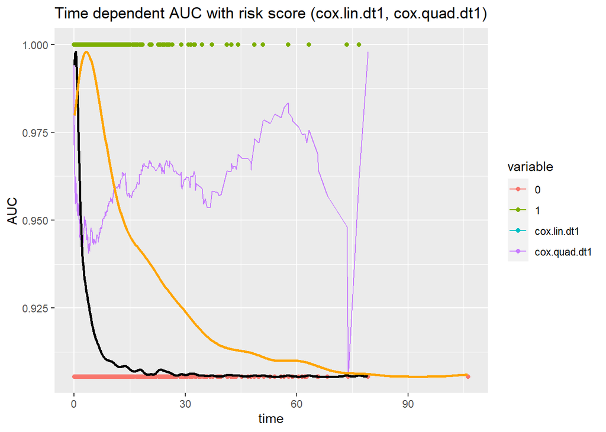

```r
dt1$censor1 <- ifelse(dt1$censor==1,
                    1,min(na.omit(ROC.risk.lin.dt1[["AUC"]])))
ggplot() +
  geom_line(data=res1, aes(x=time, y=value,
                            group=variable, color=variable)) +
  geom_point(data=dt1, aes(x=time, y=censor1, color=as.factor(censor))) +
  geom_line(data=data1_1, aes(x=time, y=density.adjusted),
            size=1, colour='black') +
  geom_line(data=data1_2, aes(x=time, y=density.adjusted),
            size=1, colour='orange') +
  scale_x_continuous(limits = c(min(dt1$time), max(dt1$time))) +
  ggtitle("Time dependent AUC with risk score (cox.lin.dt1, cox.quad.dt1)") +
  xlab("time") + ylab("AUC") +
  theme(plot.title = element_text(hjust = 0.5))
```

#### Mean value of Time dependent AUC (cox.lin.dt1, cox.quad.dt1)

```r
mean(ROC.risk.lin.dt1[["AUC"]],na.rm=TRUE)
```

```
## [1] 0.9571946
```

```r
mean(ROC.risk.quad.dt1[["AUC"]],na.rm=TRUE)
```

```
## [1] 0.9571946
```

#### Counting censored data

```r
dt1.censor <- dt1[dt1$censor==0,]
dt1.censor <- dt1.censor %>%
  mutate(n.cen=cut(dt1.censor$time,
                   breaks=seq(from=0,to=200,by=5)))
table(dt1.censor$n.cen)
```

```
##
##     (0,5]    (5,10]   (10,15]   (15,20]   (20,25]   (25,30]   (30,35]   (35,40]
##       149        75        45        37        29        23        14        11
##   (40,45]   (45,50]   (50,55]   (55,60]   (60,65]   (65,70]   (70,75]   (75,80]
##         7         9         3         5         4         3         1         1
##   (80,85]   (85,90]   (90,95]  (95,100] (100,105] (105,110] (110,115] (115,120]
##         0         0         0         0         0         1         0         0
## (120,125] (125,130] (130,135] (135,140] (140,145] (145,150] (150,155] (155,160]
##         0         0         0         0         0         0         0         0
## (160,165] (165,170] (170,175] (175,180] (180,185] (185,190] (190,195] (195,200]
##         0         0         0         0         0         0         0         0
```

## Assume quadratic relationship

```r
# Assume parametric basis distribution is Exponential distribution...
lambda1 <- 0.1 # parameter for generate Y
lambda2 <- 0.05 # parameter for generate C
beta1 <- 3 ; beta2 <- 2 # true coefficients
Y <- c() # real survival time
C <- c() # censoring time
t <- c() # observed survival time
censor <- c() # censoring indicator
X <- c() # explanatory variable
U1 <- c() # random variable from U(0,1) for generate Y
U2 <- c() # random variable from U(0,1) for generate C
X2 <- c() # X^2

for (i in 1:1000) {
  U1[i] <- runif(1)
  U2[i] <- runif(1)
  # X[i] <- runif(1,min=0,max=10)
  X[i] <- rnorm(1,mean=0,sd=1)
  X2[i] <- X[i]^2
  Y[i] <- -(1/lambda1)*log(U1[i])*exp(-beta1*X[i]-beta2*X2[i])
  C[i] <- -(1/lambda2)*log(U2[i])
  t[i] <- min(Y[i],C[i])
  censor[i] <- ifelse(Y[i]<=C[i],1,0)
}

mean(1-censor) # censoring rate
```

```
## [1] 0.266
```

```r
dt2 <- data.frame(X=X, X2=X2, Y=Y, C=C, time=t, censor=censor)
head(dt2,20)
```

```
##             X        X2           Y          C        time censor
## 1   0.4348936 0.1891325  1.42014522  0.3760856  0.37608565      0
## 2   0.7141584 0.5100222  0.29718403  0.5305952  0.29718403      1
## 3  -0.9442080 0.8915287 17.39265957 17.6762321 17.39265957      1
## 4  -0.3651842 0.1333595  0.48882963  0.7360511  0.48882963      1
## 5   0.3557526 0.1265599  0.75037202 14.0908349  0.75037202      1
## 6  -0.8964705 0.8036594 23.59953750 12.9494652 12.94946516      0
## 7  -0.3930973 0.1545255  3.15133821 51.2200181  3.15133821      1
## 8   0.8661537 0.7502223  0.17923772  3.2194473  0.17923772      1
## 9  -1.6617944 2.7615605  1.49042541 40.1296211  1.49042541      1
## 10  0.4796223 0.2300375  0.63066400 31.6211818  0.63066400      1
## 11 -2.1302463 4.5379494  1.45284436 17.3746859  1.45284436      1
## 12  0.4289380 0.1839878  0.15133881 49.2926057  0.15133881      1
## 13  1.0018208 1.0036449  0.29361383 17.7647766  0.29361383      1
## 14  0.6345891 0.4027033  1.22037366  3.7373623  1.22037366      1
## 15 -0.3493621 0.1220539 10.50466153  3.7254218  3.72542184      0
## 16 -0.6885726 0.4741322 25.04579735 16.6218878 16.62188783      0
## 17  1.0156441 1.0315329  0.09517233 45.6622007  0.09517233      1
## 18  0.6929413 0.4801677  0.91349124 10.9424650  0.91349124      1
## 19  1.2420674 1.5427315  0.02717560  6.7797314  0.02717560      1
## 20 -0.9743109 0.9492818 15.81381343 25.1195682 15.81381343      1
```

```r
# dt2[c(order(dt2$time)),]$censor
```

### Time dependent AUC

### True model

- $h(t|x)=h _{0} (t)exp[f(x)]$
- $f(x)=\beta_{1} x + \beta_{2} x^2$
- True coefficients : $\beta_{1}=3, \beta_{2}=2$

### Set linear model

- $h(t|x)=h _{0} (t)exp[f(x)]$
- $f(x)=\beta_{1}x$

```r
cox.lin.dt2 <- coxph(Surv(time,censor) ~ X, data=dt2)
summary(cox.lin.dt2)
```

```
## Call:
## coxph(formula = Surv(time, censor) ~ X, data = dt2)
##
##   n= 1000, number of events= 734
##
##      coef exp(coef) se(coef)    z Pr(>|z|)
## X 1.90536   6.72185  0.08038 23.7   <2e-16 ***
## ---
## Signif. codes:  0 '***' 0.001 '**' 0.01 '*' 0.05 '.' 0.1 ' ' 1
##
##   exp(coef) exp(-coef) lower .95 upper .95
## X     6.722     0.1488     5.742     7.869
##
## Concordance= 0.81  (se = 0.011 )
## Likelihood ratio test= 753  on 1 df,   p=<2e-16
## Wald test            = 561.9  on 1 df,   p=<2e-16
## Score (logrank) test = 618.8  on 1 df,   p=<2e-16
```

```r
risk.lin.dt2 <- predict(object=cox.lin.dt2, newdata=dt2, type="risk") # risk score
dt2$risk.lin.dt2 <- risk.lin.dt2
ROC.risk.lin.dt2 <- timeROC(T=dt2$time,
                         delta=dt2$censor,marker=dt2$risk.lin.dt2,
                         cause=1,weighting="marginal",
                         times=dt2$time)
ROC.risk.lin.dt2
```

```
## Time-dependent-Roc curve estimated using IPCW  (n=1000, without competing risks).
##                        Cases Survivors Censored AUC (%)
## t=1.42004918226728e-12     0       999        1      NA
## t=0.13465341362455       246       749        5   92.36
## t=1.6311368101328        453       500       47   86.11
## t=6.95610255229791       603       250      147   82.02
## t=71.6941230617568       733         0      267      NA
##
## Method used for estimating IPCW:marginal
##
## Total computation time : 0.8  secs.
```

### Set quadratic model

- $h(t|x)=h _{0} (t)exp[f(x)]$
- $f(x)=\beta_{1}x+\beta_{2}x^2$

```r
cox.quad.dt2 <- coxph(Surv(time,censor) ~ X+X2, data=dt2)
summary(cox.quad.dt2)
```

```
## Call:
## coxph(formula = Surv(time, censor) ~ X + X2, data = dt2)
##
##   n= 1000, number of events= 734
##
##        coef exp(coef) se(coef)     z Pr(>|z|)
## X   2.75930  15.78872  0.08499 32.47   <2e-16 ***
## X2  1.79686   6.03066  0.05963 30.13   <2e-16 ***
## ---
## Signif. codes:  0 '***' 0.001 '**' 0.01 '*' 0.05 '.' 0.1 ' ' 1
##
##    exp(coef) exp(-coef) lower .95 upper .95
## X     15.789    0.06334    13.366    18.650
## X2     6.031    0.16582     5.365     6.778
##
## Concordance= 0.877  (se = 0.007 )
## Likelihood ratio test= 1733  on 2 df,   p=<2e-16
## Wald test            = 1086  on 2 df,   p=<2e-16
## Score (logrank) test = 2647  on 2 df,   p=<2e-16
```

```r
risk.quad.dt2 <- predict(object=cox.quad.dt2, newdata=dt2, type="risk") # risk score
dt2$risk.quad.dt2 <- risk.quad.dt2
ROC.risk.quad.dt2 <- timeROC(T=dt2$time,
                         delta=dt2$censor,marker=dt2$risk.quad.dt2,
                         cause=1,weighting="marginal",
                         times=dt2$time)
ROC.risk.quad.dt2
```

```
## Time-dependent-Roc curve estimated using IPCW  (n=1000, without competing risks).
##                        Cases Survivors Censored AUC (%)
## t=1.42004918226728e-12     0       999        1      NA
## t=0.13465341362455       246       749        5   97.07
## t=1.6311368101328        453       500       47   93.80
## t=6.95610255229791       603       250      147   90.55
## t=71.6941230617568       733         0      267      NA
##
## Method used for estimating IPCW:marginal
##
## Total computation time : 0.71  secs.
```

#### Make AUC data

```r
# uncensored
uncensored.density2 <- density(dt2$time[dt2$censor==1])
data2_1 <- data.frame(time=uncensored.density2[["x"]],
                    density=uncensored.density2[["y"]])
data2_1$density.adjusted <- (max(na.omit(ROC.risk.lin.dt2[["AUC"]]))-min(na.omit(ROC.risk.lin.dt2[["AUC"]])))*(uncensored.density2[["y"]]-min(uncensored.density2[["y"]]))/(max(uncensored.density2[["y"]])-min(uncensored.density2[["y"]]))+min(na.omit(ROC.risk.lin.dt2[["AUC"]]))

# censored
censored.density2 <- density(dt2$time[dt2$censor==0])
data2_2 <- data.frame(time=censored.density2[["x"]],
                    density=censored.density2[["y"]])
data2_2$density.adjusted <- (max(na.omit(ROC.risk.lin.dt2[["AUC"]]))-min(na.omit(ROC.risk.lin.dt2[["AUC"]])))*(censored.density2[["y"]]-min(censored.density2[["y"]]))/(max(censored.density2[["y"]])-min(censored.density2[["y"]]))+min(na.omit(ROC.risk.lin.dt2[["AUC"]]))

res2 <- data.frame(time=ROC.risk.lin.dt2[["times"]],
                    cox.lin.dt2=ROC.risk.lin.dt2[["AUC"]],
                    cox.quad.dt2=ROC.risk.quad.dt2[["AUC"]])
res2 <- melt(data = res2,
                   id.vars = "time",
                   measure.vars = c("cox.lin.dt2","cox.quad.dt2"))
```

#### Time dependent AUC plot with ggplot2 (cox.lin.dt2, cox.quad.dt2)

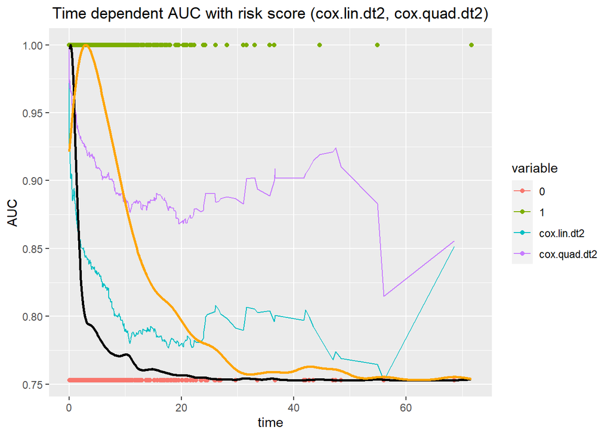

```r
dt2$censor1 <- ifelse(dt2$censor==1,
                    1,min(na.omit(ROC.risk.lin.dt2[["AUC"]])))
ggplot() +
  geom_line(data=res2, aes(x=time, y=value,
                            group=variable, color=variable)) +
  geom_point(data=dt2, aes(x=time, y=censor1, color=as.factor(censor))) +
  geom_line(data=data2_1, aes(x=time, y=density.adjusted),
            size=1, colour='black') +
  geom_line(data=data2_2, aes(x=time, y=density.adjusted),
            size=1, colour='orange') +
  scale_x_continuous(limits = c(min(dt2$time), max(dt2$time))) +
  ggtitle("Time dependent AUC with risk score (cox.lin.dt2, cox.quad.dt2)") +
  xlab("time") + ylab("AUC") +
  theme(plot.title = element_text(hjust = 0.5))
```

#### Mean value of Time dependent AUC (cox.lin.dt2, cox.quad.dt2)

```r
mean(ROC.risk.lin.dt2[["AUC"]],na.rm=TRUE)
```

```
## [1] 0.8709298
```

```r
mean(ROC.risk.quad.dt2[["AUC"]],na.rm=TRUE)
```

```
## [1] 0.9362839
```

#### Counting censored data

```r
dt2.censor <- dt2[dt2$censor==0,]
dt2.censor <- dt2.censor %>%
  mutate(n.cen=cut(dt2.censor$time,
                   breaks=seq(from=0,to=200,by=5)))
table(dt2.censor$n.cen)
```

```
##
##     (0,5]    (5,10]   (10,15]   (15,20]   (20,25]   (25,30]   (30,35]   (35,40]
##       112        71        32        21        11         7         1         2
##   (40,45]   (45,50]   (50,55]   (55,60]   (60,65]   (65,70]   (70,75]   (75,80]
##         4         3         0         1         0         1         0         0
##   (80,85]   (85,90]   (90,95]  (95,100] (100,105] (105,110] (110,115] (115,120]
##         0         0         0         0         0         0         0         0
## (120,125] (125,130] (130,135] (135,140] (140,145] (145,150] (150,155] (155,160]
##         0         0         0         0         0         0         0         0
## (160,165] (165,170] (170,175] (175,180] (180,185] (185,190] (190,195] (195,200]
##         0         0         0         0         0         0         0         0
```

## Compare two results

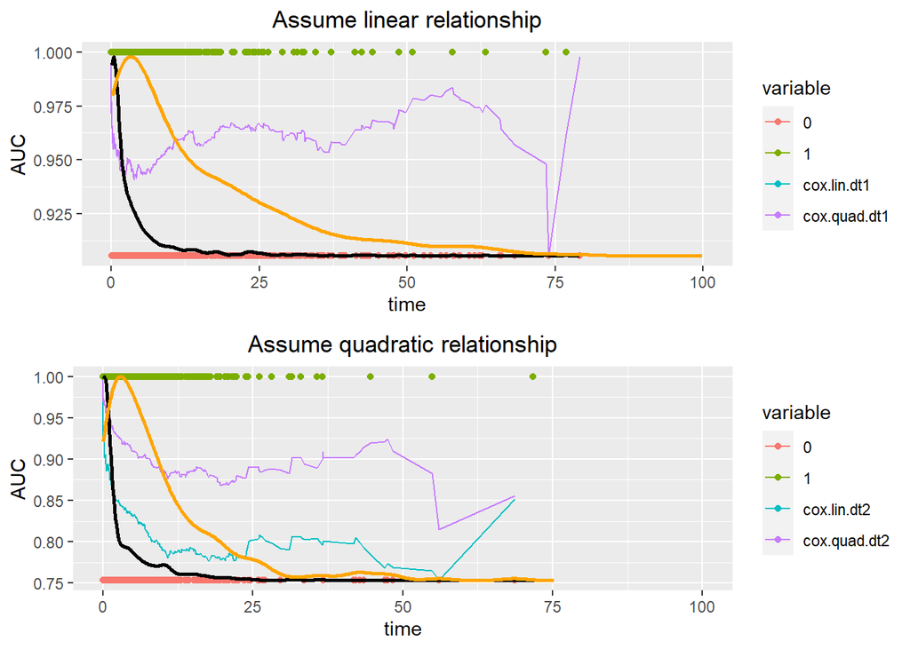

```r
a <- ggplot()

fig1 <- a +
  geom_line(data=res1, aes(x=time, y=value,
                            group=variable, color=variable)) +
  geom_point(data=dt1, aes(x=time, y=censor1, color=as.factor(censor))) +
  geom_line(data=data1_1, aes(x=time, y=density.adjusted),
            size=1, colour='black') +
  geom_line(data=data1_2, aes(x=time, y=density.adjusted),
            size=1, colour='orange') +
  scale_x_continuous(limits = c(0, 100)) +
  ggtitle("Assume linear relationship") +
  xlab("time") + ylab("AUC") +
  theme(plot.title = element_text(hjust = 0.5))

fig2 <- a +
  geom_line(data=res2, aes(x=time, y=value,
                            group=variable, color=variable)) +
  geom_point(data=dt2, aes(x=time, y=censor1, color=as.factor(censor))) +
  geom_line(data=data2_1, aes(x=time, y=density.adjusted),
            size=1, colour='black') +
  geom_line(data=data2_2, aes(x=time, y=density.adjusted),
            size=1, colour='orange') +
  scale_x_continuous(limits = c(0, 100)) +
  ggtitle("Assume quadratic relationship") +
  xlab("time") + ylab("AUC") +
  theme(plot.title = element_text(hjust = 0.5))

grid.arrange(fig1, fig2, nrow=2, ncol=1)
```

### Assume linear relationship

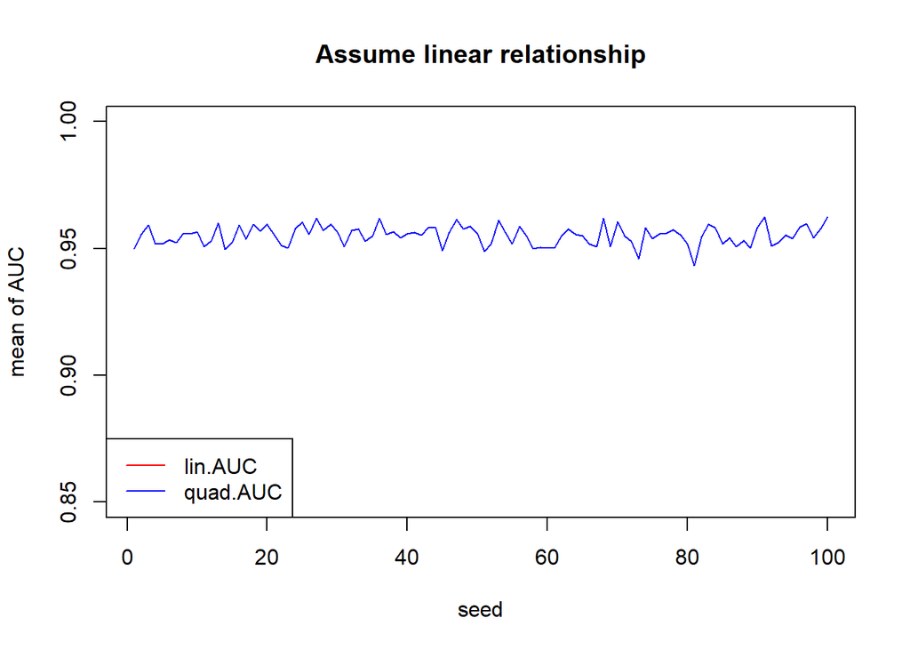

```r
seed <- c()
lin.AUC <- c()
quad.AUC <- c()

for (i in 1:100) {

  # Assume parametric basis distribution is Exponential distribution...
  lambda1 <- 0.1 # parameter for generate Y
  lambda2 <- 0.05 # parameter for generate C
  beta1 <- 3 # true coefficients
  Y <- c() # real survival time
  C <- c() # censoring time
  t <- c() # observed survival time
  censor <- c() # censoring indicator
  X <- c() # explanatory variable
  U1 <- c() # random variable from U(0,1) for generate Y
  U2 <- c() # random variable from U(0,1) for generate C
  X2 <- c() # X^2

  # Generate simulation data (Assume linear relationship)
  seed[i] <- i
  set.seed(i)
  for (j in 1:1000) {
    U1[j] <- runif(1)
    U2[j] <- runif(1)
    X[j] <- rnorm(1,mean=0,sd=1)
    X2[j] <- X[j]^2
    Y[j] <- -(1/lambda1)*log(U1[j])*exp(-beta1*X[j])
    C[j] <- -(1/lambda2)*log(U2[j])
    t[j] <- min(Y[j],C[j])
    censor[j] <- ifelse(Y[j]<=C[j],1,0)
  }
  dt1 <- data.frame(X=X, X2=X2, Y=Y, C=C, time=t, censor=censor)

  # Set linear model
  cox.lin.dt1 <- coxph(Surv(time,censor) ~ X, data=dt1)
  risk.lin.dt1 <- predict(object=cox.lin.dt1, newdata=dt1, type="risk")
  dt1$risk.lin.dt1 <- risk.lin.dt1
  ROC.risk.lin.dt1 <- timeROC(T=dt1$time,
                         delta=dt1$censor,marker=dt1$risk.lin.dt1,
                         cause=1,weighting="marginal",
                         times=dt1$time)

  # Set quadratic model
  cox.quad.dt1 <- coxph(Surv(time,censor) ~ X+X2, data=dt1)
  risk.quad.dt1 <- predict(object=cox.quad.dt1, newdata=dt1, type="risk")
  dt1$risk.quad.dt1 <- risk.quad.dt1
  ROC.risk.quad.dt1 <- timeROC(T=dt1$time,
                         delta=dt1$censor,marker=dt1$risk.quad.dt1,
                         cause=1,weighting="marginal",
                         times=dt1$time)

  # Calculate mean value of time dependent AUC
  lin.AUC[i] <- mean(ROC.risk.lin.dt1[["AUC"]],na.rm=TRUE)
  quad.AUC[i] <- mean(ROC.risk.quad.dt1[["AUC"]],na.rm=TRUE)

  # print(i)

}

dat1 <- data.frame(seed=seed, lin.AUC=lin.AUC, quad.AUC=quad.AUC)
plot(x=dat1$seed, y=dat1$lin.AUC, xlab="seed", ylab="mean of AUC",
     main="Assume linear relationship", type="l", col="red", ylim=c(0.85,1))
lines(x=dat1$seed, y=dat1$quad.AUC, type="l", col="blue")
legend("bottomleft",c("lin.AUC","quad.AUC"),col=c("red","blue"),lty=c(1,1))
```

### Assume quadratic relationship

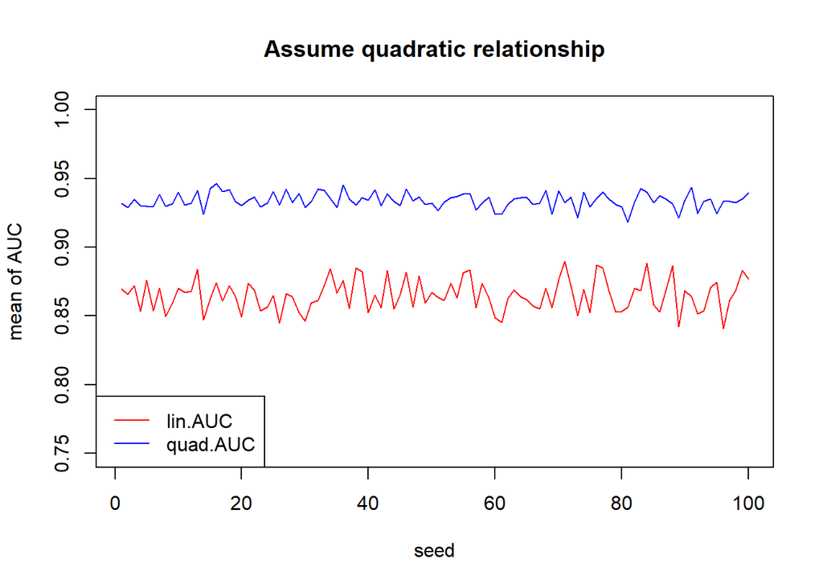

```r
seed <- c()
lin.AUC <- c()
quad.AUC <- c()

for (i in 1:100) {

  # Assume parametric basis distribution is Exponential distribution...
  lambda1 <- 0.1 # parameter for generate Y
  lambda2 <- 0.05 # parameter for generate C
  beta1 <- 3 ; beta2 <- 2 # true coefficients
  Y <- c() # real survival time
  C <- c() # censoring time
  t <- c() # observed survival time
  censor <- c() # censoring indicator
  X <- c() # explanatory variable
  U1 <- c() # random variable from U(0,1) for generate Y
  U2 <- c() # random variable from U(0,1) for generate C
  X2 <- c() # X^2

  # Generate simulation data (Assume quadratic relationship)
  seed[i] <- i
  set.seed(i)
  for (j in 1:1000) {
    U1[j] <- runif(1)
    U2[j] <- runif(1)
    X[j] <- rnorm(1,mean=0,sd=1)
    X2[j] <- X[j]^2
    Y[j] <- -(1/lambda1)*log(U1[j])*exp(-beta1*X[j]-beta2*X2[j])
    C[j] <- -(1/lambda2)*log(U2[j])
    t[j] <- min(Y[j],C[j])
    censor[j] <- ifelse(Y[j]<=C[j],1,0)
  }
  dt2 <- data.frame(X=X, X2=X2, Y=Y, C=C, time=t, censor=censor)

  # Set linear model
  cox.lin.dt2 <- coxph(Surv(time,censor) ~ X, data=dt2)
  risk.lin.dt2 <- predict(object=cox.lin.dt2, newdata=dt2, type="risk")
  dt2$risk.lin.dt2 <- risk.lin.dt2
  ROC.risk.lin.dt2 <- timeROC(T=dt2$time,
                         delta=dt2$censor,marker=dt2$risk.lin.dt2,
                         cause=1,weighting="marginal",
                         times=dt2$time)

  # Set quadratic model
  cox.quad.dt2 <- coxph(Surv(time,censor) ~ X+X2, data=dt2)
  risk.quad.dt2 <- predict(object=cox.quad.dt2, newdata=dt2, type="risk")
  dt2$risk.quad.dt2 <- risk.quad.dt2
  ROC.risk.quad.dt2 <- timeROC(T=dt2$time,
                         delta=dt2$censor,marker=dt2$risk.quad.dt2,
                         cause=1,weighting="marginal",
                         times=dt2$time)

  # Calculate mean value of time dependent AUC
  lin.AUC[i] <- mean(ROC.risk.lin.dt2[["AUC"]],na.rm=TRUE)
  quad.AUC[i] <- mean(ROC.risk.quad.dt2[["AUC"]],na.rm=TRUE)

  # print(i)
}

dat2 <- data.frame(seed=seed, lin.AUC=lin.AUC, quad.AUC=quad.AUC)
plot(x=dat2$seed, y=dat2$lin.AUC, xlab="seed", ylab="mean of AUC",
     main="Assume quadratic relationship", type="l", col="red", ylim=c(0.75,1))
lines(x=dat2$seed, y=dat2$quad.AUC, type="l", col="blue")
legend("bottomleft",c("lin.AUC","quad.AUC"),col=c("red","blue"),lty=c(1,1))
```

# Set other distributions

## Background

`-` real survival time $Y$ : Exponential distribution `-` censoring time $C$ : Uniform distribution

- $h(t|x)=h_{0}(t)exp(f(x))$
- $H(t|x)=\int_{0}^{t} h(s|x)ds= \int_{0}^{t} h_{0}(s)exp(f(x))ds=H_{0}(t)exp(f(x))$
- $h(t|x)=\frac {f(t|x)}{S(t|x)}= -\frac {d}{dt} log[S(t|x)]$
- $log[S(t|x)]= -\int_{0}^{t} h(s|x)ds= -H(t|x)= -H_{0}(t)exp(f(x))$
- $S(t|x)=exp[-H_{0}(t)exp(f(x))]$
- In general,…
- $F(t|x)=1-exp[-H_{0}(t) exp(f(x))]$
- -> $F^{-1}(t|x)=H_{0}^{-1}[-log(1-t) exp(-f(x))]$
- By Inverse Transform Sampling, suppose that $U_{1}, U_{2} \overset{i.i.d}{\sim}\ U(0,1)$, then we can generate real survival time $Y$ from Cox Proportional Hazard Model using this equation.
- $Y=H_{Y0}^{-1}[-log(U_{1})exp(-f(x))]$
- And by assuming non-informative censoring, we can generate censoring time $C$ like this equation. (Set $Y$ and $C$ are independent each other.)
- $C=H_{C0}^{-1}[-log(U_{2})]$
- And set censoring indicator $\delta=I(Y \leq C)$ and observed survival time $T=min(Y,C)$
- $H_{Y0}(t|x)$ : Basis cumulative hazard function of real survival time $Y$
- $H_{C0}(t)$ : Basis cumulative hazard function of censoring time $C$
- When parametric basis distribution of real survival time $Y$ is Exponential distribution and parametric basis distribution of censoring time $C$ is Uniform distribution ($Y$ and $C$ are independent each other), then ~
- $Y$ : $f_{Y0}(t)=\lambda e^{-\lambda t}, t>0$ -> $S_{Y0}(t)=e^{-\lambda t}$ -> $h_{Y0}(t)=\lambda$
- $C$ : $f_{C0}(t)=\frac {1}{\lambda}, 0<t<\lambda$ -> $S_{C0}(t)=1-\frac {t}{\lambda}$ -> $h_{C0}(t)=\frac {1}{\lambda -t}$
- $\therefore Y=-\frac{1}{\lambda_{1}} log(U_{1}) exp(-f(x))$, $C=\lambda_{2}(1-U_{2})$

# Generating simulation data

## Assume linear relationship

```r
# Assume parametric basis distribution is Exponential distribution...
lambda1 <- 0.001 # parameter for generate Y
lambda2 <- 2/lambda1 # parameter for generate C
beta1 <- 3 # true coefficients
Y <- c() # real survival time
C <- c() # censoring time
t <- c() # observed survival time
censor <- c() # censoring indicator
X <- c() # explanatory variable
U1 <- c() # random variable from U(0,1) for generate Y
U2 <- c() # random variable from U(0,1) for generate C
X2 <- c() # X^2

for (i in 1:1000) {
  U1[i] <- runif(1)
  U2[i] <- runif(1)
  # X[i] <- runif(1,min=0,max=10)
  X[i] <- rnorm(1,mean=0,sd=1)
  X2[i] <- X[i]^2
  Y[i] <- -(1/lambda1)*log(U1[i])*exp(-beta1*X[i])
  C[i] <- (lambda2)*(1-U2[i])
  t[i] <- min(Y[i],C[i])
  censor[i] <- ifelse(Y[i]<=C[i],1,0)
}

mean(1-censor) # censoring rate
```

```
## [1] 0.476
```

```r
dt3 <- data.frame(X=X, X2=X2, Y=Y, C=C, time=t, censor=censor)
head(dt3,20)
```

```
##              X          X2            Y         C       time censor
## 1  -0.22974319 0.052781932 1.850192e+02 1296.8210  185.01917      1
## 2  -0.62730903 0.393516613 2.087908e+04 1757.4853 1757.48527      0
## 3  -1.33757722 1.789112819 4.998618e+04 1419.0233 1419.02327      0
## 4  -0.55237209 0.305114920 2.713483e+03 1103.7668 1103.76676      0
## 5   0.14826603 0.021982815 1.280330e+03 1157.7561 1157.75612      0
## 6  -1.01110909 1.022341586 2.125637e+03  631.1085  631.10854      0
## 7  -0.82717384 0.684216566 3.015893e+04  479.5197  479.51965      0
## 8  -0.11204886 0.012554947 1.665521e+03 1699.0075 1665.52125      1
## 9   0.35035553 0.122749000 7.501473e+02 1100.2288  750.14733      1
## 10 -0.77985061 0.608166970 3.861652e+03  536.3205  536.32054      0
## 11 -1.68586337 2.842135301 2.700681e+05  447.0803  447.08029      0
## 12 -0.19549731 0.038219198 2.839368e+02  816.4481  283.93681      1
## 13 -0.06422923 0.004125394 1.077688e+03  320.2645  320.26447      0
## 14 -0.61945799 0.383728196 3.338613e+03 1998.4552 1998.45520      0
## 15  0.29187426 0.085190582 3.244262e+02 1436.0846  324.42621      1
## 16  0.06130790 0.003758658 9.727688e+02  464.1740  464.17401      0
## 17 -2.89899964 8.404198900 8.197670e+06 1416.7499 1416.74989      0
## 18  0.49882343 0.248824811 3.082874e+01 1504.4577   30.82874      1
## 19 -1.07926902 1.164821613 1.374990e+04 1894.9730 1894.97295      0
## 20  0.81280352 0.660649559 1.126824e+02 1684.1625  112.68238      1
```

```r
# dt3[c(order(dt3$time)),]$censor
```

### Time dependent AUC

### True model

- $h(t|x)=h _{0} (t)exp[f(x)]$
- $f(x)=\beta_{1} x$
- True coefficients : $\beta_{1}=3$

### Set linear model

- $h(t|x)=h _{0} (t)exp[f(x)]$
- $f(x)=\beta_{1}x$

```r
cox.lin.dt3 <- coxph(Surv(time,censor) ~ X, data=dt3)
summary(cox.lin.dt3)
```

```
## Call:
## coxph(formula = Surv(time, censor) ~ X, data = dt3)
##
##   n= 1000, number of events= 524
##
##      coef exp(coef) se(coef)     z Pr(>|z|)
## X  3.0277   20.6488   0.1029 29.41   <2e-16 ***
## ---
## Signif. codes:  0 '***' 0.001 '**' 0.01 '*' 0.05 '.' 0.1 ' ' 1
##
##   exp(coef) exp(-coef) lower .95 upper .95
## X     20.65    0.04843     16.88     25.26
##
## Concordance= 0.896  (se = 0.006 )
## Likelihood ratio test= 1372  on 1 df,   p=<2e-16
## Wald test            = 865  on 1 df,   p=<2e-16
## Score (logrank) test = 983.6  on 1 df,   p=<2e-16
```

```r
risk.lin.dt3 <- predict(object=cox.lin.dt3, newdata=dt3, type="risk") # risk score
dt3$risk.lin.dt3 <- risk.lin.dt3
ROC.risk.lin.dt3 <- timeROC(T=dt3$time,
                         delta=dt3$censor,marker=dt3$risk.lin.dt3,
                         cause=1,weighting="marginal",
                         times=dt3$time)
ROC.risk.lin.dt3
```

```
## Time-dependent-Roc curve estimated using IPCW  (n=1000, without competing risks).
##                      Cases Survivors Censored AUC (%)
## t=0.0179979018132785     0       999        1      NA
## t=51.2946341186762     226       749       25   94.32
## t=287.286725476819     397       500      103   95.10
## t=864.674234762788     493       250      257   96.10
## t=1999.12702711299     524         0      476      NA
##
## Method used for estimating IPCW:marginal
##
## Total computation time : 0.56  secs.
```

### Set quadratic model

- $h(t|x)=h _{0} (t)exp[f(x)]$
- $f(x)=\beta_{1}x+\beta_{2}x^2$

```r
cox.quad.dt3 <- coxph(Surv(time,censor) ~ X+X2, data=dt3)
summary(cox.quad.dt3)
```

```
## Call:
## coxph(formula = Surv(time, censor) ~ X + X2, data = dt3)
##
##   n= 1000, number of events= 524
##
##        coef exp(coef) se(coef)      z Pr(>|z|)
## X   2.95711  19.24234  0.13558 21.812   <2e-16 ***
## X2  0.05737   1.05905  0.07406  0.775    0.439
## ---
## Signif. codes:  0 '***' 0.001 '**' 0.01 '*' 0.05 '.' 0.1 ' ' 1
##
##    exp(coef) exp(-coef) lower .95 upper .95
## X     19.242    0.05197    14.752    25.099
## X2     1.059    0.94425     0.916     1.224
##
## Concordance= 0.896  (se = 0.006 )
## Likelihood ratio test= 1372  on 2 df,   p=<2e-16
## Wald test            = 884.6  on 2 df,   p=<2e-16
## Score (logrank) test = 1902  on 2 df,   p=<2e-16
```

```r
risk.quad.dt3 <- predict(object=cox.quad.dt3, newdata=dt3, type="risk") # risk score
dt3$risk.quad.dt3 <- risk.quad.dt3
ROC.risk.quad.dt3 <- timeROC(T=dt3$time,
                         delta=dt3$censor,marker=dt3$risk.quad.dt3,
                         cause=1,weighting="marginal",
                         times=dt3$time)
ROC.risk.quad.dt3
```

```
## Time-dependent-Roc curve estimated using IPCW  (n=1000, without competing risks).
##                      Cases Survivors Censored AUC (%)
## t=0.0179979018132785     0       999        1      NA
## t=51.2946341186762     226       749       25   94.32
## t=287.286725476819     397       500      103   95.10
## t=864.674234762788     493       250      257   96.10
## t=1999.12702711299     524         0      476      NA
##
## Method used for estimating IPCW:marginal
##
## Total computation time : 0.83  secs.
```

#### Make AUC data

```r
# uncensored
uncensored.density3 <- density(dt3$time[dt3$censor==1])
data3_1 <- data.frame(time=uncensored.density3[["x"]],
                    density=uncensored.density3[["y"]])
data3_1$density.adjusted <- (max(na.omit(ROC.risk.lin.dt3[["AUC"]]))-min(na.omit(ROC.risk.lin.dt3[["AUC"]])))*(uncensored.density3[["y"]]-min(uncensored.density3[["y"]]))/(max(uncensored.density3[["y"]])-min(uncensored.density3[["y"]]))+min(na.omit(ROC.risk.lin.dt3[["AUC"]]))

# censored
censored.density3 <- density(dt3$time[dt3$censor==0])
data3_2 <- data.frame(time=censored.density3[["x"]],
                    density=censored.density3[["y"]])
data3_2$density.adjusted <- (max(na.omit(ROC.risk.lin.dt3[["AUC"]]))-min(na.omit(ROC.risk.lin.dt3[["AUC"]])))*(censored.density3[["y"]]-min(censored.density3[["y"]]))/(max(censored.density3[["y"]])-min(censored.density3[["y"]]))+min(na.omit(ROC.risk.lin.dt3[["AUC"]]))

res3 <- data.frame(time=ROC.risk.lin.dt3[["times"]],
                    cox.lin.dt3=ROC.risk.lin.dt3[["AUC"]],
                    cox.quad.dt3=ROC.risk.quad.dt3[["AUC"]])
res3 <- melt(data = res3,
                   id.vars = "time",
                   measure.vars = c("cox.lin.dt3","cox.quad.dt3"))
```

#### Time dependent AUC plot with ggplot2 (cox.lin.dt3, cox.quad.dt3)

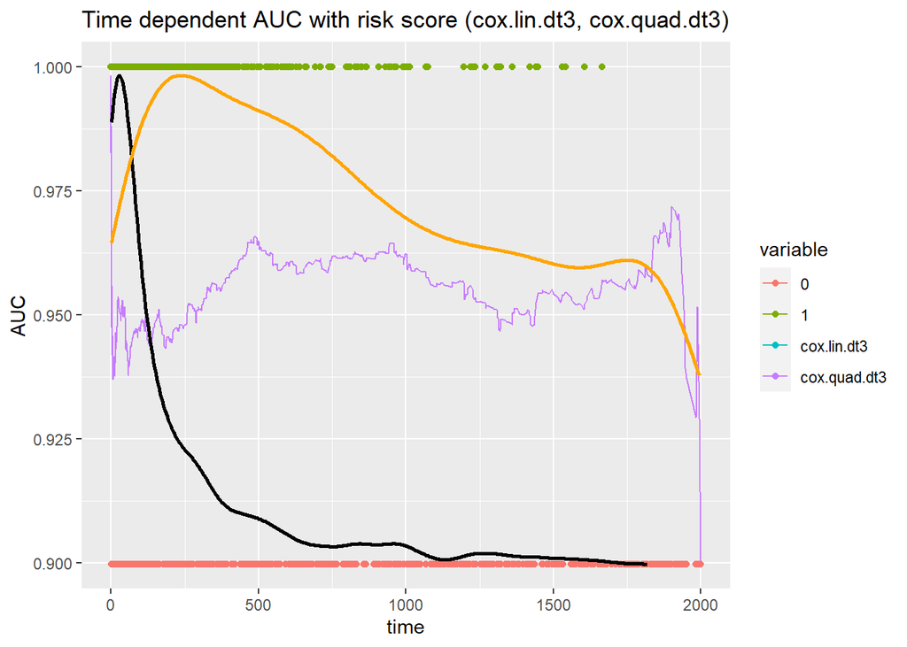

```r
dt3$censor1 <- ifelse(dt3$censor==1,
                    1,min(na.omit(ROC.risk.lin.dt3[["AUC"]])))
ggplot() +
  geom_line(data=res3, aes(x=time, y=value,
                            group=variable, color=variable)) +
  geom_point(data=dt3, aes(x=time, y=censor1, color=as.factor(censor))) +
  geom_line(data=data3_1, aes(x=time, y=density.adjusted),
            size=1, colour='black') +
  geom_line(data=data3_2, aes(x=time, y=density.adjusted),
            size=1, colour='orange') +
  scale_x_continuous(limits = c(min(dt3$time), max(dt3$time))) +
  ggtitle("Time dependent AUC with risk score (cox.lin.dt3, cox.quad.dt3)") +
  xlab("time") + ylab("AUC") +
  theme(plot.title = element_text(hjust = 0.5))
```

#### Mean value of Time dependent AUC (cox.lin.dt3, cox.quad.dt3)

```r
mean(ROC.risk.lin.dt3[["AUC"]],na.rm=TRUE)
```

```
## [1] 0.9535576
```

```r
mean(ROC.risk.quad.dt3[["AUC"]],na.rm=TRUE)
```

```
## [1] 0.9535576
```

#### Counting censored data

```r
dt3.censor <- dt3[dt3$censor==0,]
dt3.censor <- dt3.censor %>%
  mutate(n.cen=cut(dt3.censor$time,
                   breaks=seq(from=0,to=2500,by=100)))
table(dt3.censor$n.cen)
```

```
##
##           (0,100]         (100,200]         (200,300]         (300,400]
##                44                33                28                31
##         (400,500]         (500,600]         (600,700]         (700,800]
##                28                24                24                28
##         (800,900]       (900,1e+03]   (1e+03,1.1e+03] (1.1e+03,1.2e+03]
##                20                26                16                21
## (1.2e+03,1.3e+03] (1.3e+03,1.4e+03] (1.4e+03,1.5e+03] (1.5e+03,1.6e+03]
##                18                19                20                15
## (1.6e+03,1.7e+03] (1.7e+03,1.8e+03] (1.8e+03,1.9e+03]   (1.9e+03,2e+03]
##                17                17                26                21
##   (2e+03,2.1e+03] (2.1e+03,2.2e+03] (2.2e+03,2.3e+03] (2.3e+03,2.4e+03]
##                 0                 0                 0                 0
## (2.4e+03,2.5e+03]
##                 0
```

## Assume quadratic relationship

```r
# Assume parametric basis distribution is Exponential distribution...
lambda1 <- 0.001 # parameter for generate Y
lambda2 <- 2/lambda1 # parameter for generate C
beta1 <- 3 ; beta2 <- 2 # true coefficients
Y <- c() # real survival time
C <- c() # censoring time
t <- c() # observed survival time
censor <- c() # censoring indicator
X <- c() # explanatory variable
U1 <- c() # random variable from U(0,1) for generate Y
U2 <- c() # random variable from U(0,1) for generate C
X2 <- c() # X^2

for (i in 1:1000) {
  U1[i] <- runif(1)
  U2[i] <- runif(1)
  # X[i] <- runif(1,min=0,max=10)
  X[i] <- rnorm(1,mean=0,sd=1)
  X2[i] <- X[i]^2
  Y[i] <- -(1/lambda1)*log(U1[i])*exp(-beta1*X[i]-beta2*X2[i])
  C[i] <- (lambda2)*(1-U2[i])
  t[i] <- min(Y[i],C[i])
  censor[i] <- ifelse(Y[i]<=C[i],1,0)
}

mean(1-censor) # censoring rate
```

```
## [1] 0.318
```

```r
dt4 <- data.frame(X=X, X2=X2, Y=Y, C=C, time=t, censor=censor)
head(dt4,20)
```

```
##              X         X2            Y          C         time censor
## 1  -0.27343947 0.07476914 1.346150e+02 1055.78713 1.346150e+02      1
## 2  -0.12918348 0.01668837 1.716414e+03 1730.78490 1.716414e+03      1
## 3   0.27666677 0.07654450 4.222725e+02  717.35057 4.222725e+02      1
## 4  -0.44711210 0.19990923 1.752015e+03  641.11100 6.411110e+02      0
## 5  -1.65091214 2.72551090 3.460388e+02 1399.84312 3.460388e+02      1
## 6  -0.13803023 0.01905234 3.870989e+03 1022.62528 1.022625e+03      0
## 7   0.61056765 0.37279286 1.107081e+02  552.79721 1.107081e+02      1
## 8   0.12194705 0.01487108 1.401308e+02   15.88629 1.588629e+01      0
## 9   1.77493227 3.15038456 9.578273e-03  374.10048 9.578273e-03      1
## 10  0.85018400 0.72281283 2.376242e+01 1445.12412 2.376242e+01      1
## 11 -0.48260789 0.23291038 3.050495e+03  621.61056 6.216106e+02      0
## 12 -0.21923586 0.04806436 8.242035e+02 1194.49795 8.242035e+02      1
## 13  0.70004629 0.49006481 6.308738e+00  130.79889 6.308738e+00      1
## 14  0.09526515 0.00907545 8.424180e+02 1060.50655 8.424180e+02      1
## 15  0.45666360 0.20854164 2.829859e+01 1919.45971 2.829859e+01      1
## 16  0.23617747 0.05577980 1.819241e+02 1540.94919 1.819241e+02      1
## 17 -0.25348100 0.06425262 4.061848e+03 1227.89759 1.227898e+03      0
## 18 -0.13296078 0.01767857 7.514209e+02  160.20718 1.602072e+02      0
## 19 -1.30886723 1.71313342 2.529617e+02 1064.96658 2.529617e+02      1
## 20  0.17711800 0.03137079 1.421432e+02  446.96203 1.421432e+02      1
```

```r
# dt4[c(order(dt4$time)),]$censor
```

### Set linear model

- $h(t|x)=h _{0} (t)exp[f(x)]$
- $f(x)=\beta_{1}x$

```r
cox.lin.dt4 <- coxph(Surv(time,censor) ~ X, data=dt4)
summary(cox.lin.dt4)
```

```
## Call:
## coxph(formula = Surv(time, censor) ~ X, data = dt4)
##
##   n= 1000, number of events= 682
##
##      coef exp(coef) se(coef)     z Pr(>|z|)
## X 2.17921   8.83930  0.09008 24.19   <2e-16 ***
## ---
## Signif. codes:  0 '***' 0.001 '**' 0.01 '*' 0.05 '.' 0.1 ' ' 1
##
##   exp(coef) exp(-coef) lower .95 upper .95
## X     8.839     0.1131     7.409     10.55
##
## Concordance= 0.819  (se = 0.011 )
## Likelihood ratio test= 816.3  on 1 df,   p=<2e-16
## Wald test            = 585.3  on 1 df,   p=<2e-16
## Score (logrank) test = 662.6  on 1 df,   p=<2e-16
```

```r
risk.lin.dt4 <- predict(object=cox.lin.dt4, newdata=dt4, type="risk") # risk score
dt4$risk.lin.dt4 <- risk.lin.dt4
ROC.risk.lin.dt4 <- timeROC(T=dt4$time,
                         delta=dt4$censor,marker=dt4$risk.lin.dt4,
                         cause=1,weighting="marginal",
                         times=dt4$time)
ROC.risk.lin.dt4
```

```
## Time-dependent-Roc curve estimated using IPCW  (n=1000, without competing risks).
##                        Cases Survivors Censored AUC (%)
## t=4.82111368596028e-09     0       999        1      NA
## t=19.8981970637591       245       749        6   93.89
## t=178.41608915478        434       500       66   86.91
## t=639.72521899268        597       250      153   81.71
## t=1985.15419708565       682         0      318      NA
##
## Method used for estimating IPCW:marginal
##
## Total computation time : 0.51  secs.
```

### Set quadratic model

- $h(t|x)=h _{0} (t)exp[f(x)]$
- $f(x)=\beta_{1}x+\beta_{2}x^2$

```r
cox.quad.dt4 <- coxph(Surv(time,censor) ~ X+X2, data=dt4)
summary(cox.quad.dt4)
```

```
## Call:
## coxph(formula = Surv(time, censor) ~ X + X2, data = dt4)
##
##   n= 1000, number of events= 682
##
##        coef exp(coef) se(coef)     z Pr(>|z|)
## X   2.87000  17.63701  0.08758 32.77   <2e-16 ***
## X2  1.86512   6.45669  0.06193 30.11   <2e-16 ***
## ---
## Signif. codes:  0 '***' 0.001 '**' 0.01 '*' 0.05 '.' 0.1 ' ' 1
##
##    exp(coef) exp(-coef) lower .95 upper .95
## X     17.637     0.0567    14.855     20.94
## X2     6.457     0.1549     5.719      7.29
##
## Concordance= 0.872  (se = 0.007 )
## Likelihood ratio test= 1712  on 2 df,   p=<2e-16
## Wald test            = 1118  on 2 df,   p=<2e-16
## Score (logrank) test = 2607  on 2 df,   p=<2e-16
```

```r
risk.quad.dt4 <- predict(object=cox.quad.dt4, newdata=dt4, type="risk") # risk score
dt4$risk.quad.dt4 <- risk.quad.dt4
ROC.risk.quad.dt4 <- timeROC(T=dt4$time,
                         delta=dt4$censor,marker=dt4$risk.quad.dt4,
                         cause=1,weighting="marginal",
                         times=dt4$time)
ROC.risk.quad.dt4
```

```
## Time-dependent-Roc curve estimated using IPCW  (n=1000, without competing risks).
##                        Cases Survivors Censored AUC (%)
## t=4.82111368596028e-09     0       999        1      NA
## t=19.8981970637591       245       749        6   97.51
## t=178.41608915478        434       500       66   93.26
## t=639.72521899268        597       250      153   88.38
## t=1985.15419708565       682         0      318      NA
##
## Method used for estimating IPCW:marginal
##
## Total computation time : 0.54  secs.
```

#### Make AUC data

```r
# uncensored
uncensored.density4 <- density(dt4$time[dt4$censor==1])
data4_1 <- data.frame(time=uncensored.density4[["x"]],
                    density=uncensored.density4[["y"]])
data4_1$density.adjusted <- (max(na.omit(ROC.risk.lin.dt4[["AUC"]]))-min(na.omit(ROC.risk.lin.dt4[["AUC"]])))*(uncensored.density4[["y"]]-min(uncensored.density4[["y"]]))/(max(uncensored.density4[["y"]])-min(uncensored.density4[["y"]]))+min(na.omit(ROC.risk.lin.dt4[["AUC"]]))

# censored
censored.density4 <- density(dt4$time[dt4$censor==0])
data4_2 <- data.frame(time=censored.density4[["x"]],
                    density=censored.density4[["y"]])
data4_2$density.adjusted <- (max(na.omit(ROC.risk.lin.dt4[["AUC"]]))-min(na.omit(ROC.risk.lin.dt4[["AUC"]])))*(censored.density4[["y"]]-min(censored.density4[["y"]]))/(max(censored.density4[["y"]])-min(censored.density4[["y"]]))+min(na.omit(ROC.risk.lin.dt4[["AUC"]]))

res4 <- data.frame(time=ROC.risk.lin.dt4[["times"]],
                    cox.lin.dt4=ROC.risk.lin.dt4[["AUC"]],
                    cox.quad.dt4=ROC.risk.quad.dt4[["AUC"]])
res4 <- melt(data = res4,
                   id.vars = "time",
                   measure.vars = c("cox.lin.dt4","cox.quad.dt4"))
```

#### Time dependent AUC plot with ggplot2 (cox.lin.dt4, cox.quad.dt4)

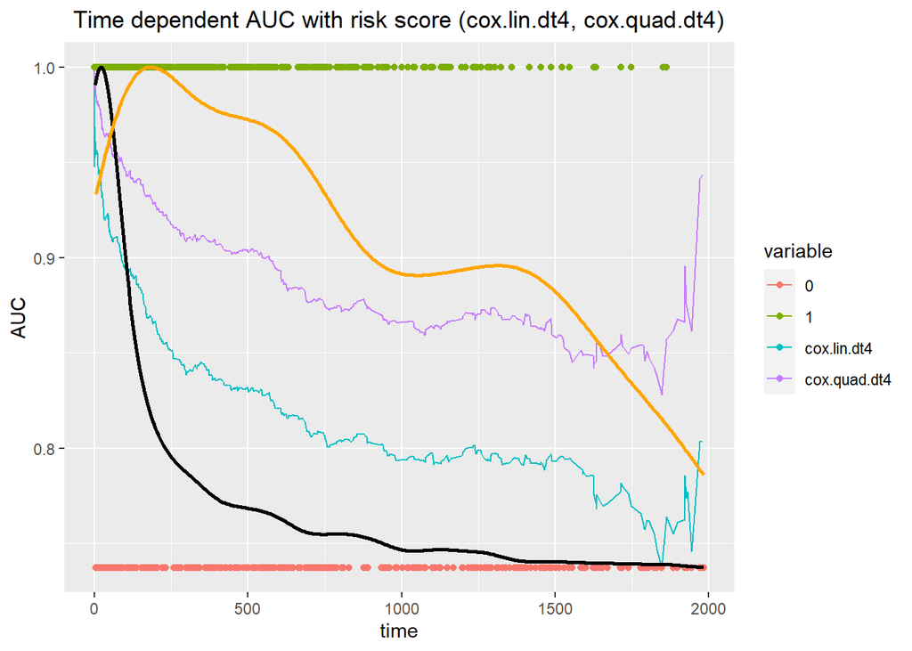

```r
dt4$censor1 <- ifelse(dt4$censor==1,
                    1,min(na.omit(ROC.risk.lin.dt4[["AUC"]])))
ggplot() +
  geom_line(data=res4, aes(x=time, y=value,
                            group=variable, color=variable)) +
  geom_point(data=dt4, aes(x=time, y=censor1, color=as.factor(censor))) +
  geom_line(data=data4_1, aes(x=time, y=density.adjusted),
            size=1, colour='black') +
  geom_line(data=data4_2, aes(x=time, y=density.adjusted),
            size=1, colour='orange') +
  scale_x_continuous(limits = c(min(dt4$time), max(dt4$time))) +
  ggtitle("Time dependent AUC with risk score (cox.lin.dt4, cox.quad.dt4)") +
  xlab("time") + ylab("AUC") +
  theme(plot.title = element_text(hjust = 0.5))
```

#### Mean value of Time dependent AUC (cox.lin.dt4, cox.quad.dt4)

```r
mean(ROC.risk.lin.dt4[["AUC"]],na.rm=TRUE)
```

```
## [1] 0.8751192
```

```r
mean(ROC.risk.quad.dt4[["AUC"]],na.rm=TRUE)
```

```
## [1] 0.9294968
```

#### Counting censored data

```r
dt4.censor <- dt4[dt4$censor==0,]
dt4.censor <- dt4.censor %>%
  mutate(n.cen=cut(dt4.censor$time,
                   breaks=seq(from=0,to=2500,by=100)))
table(dt4.censor$n.cen)
```

```
##
##           (0,100]         (100,200]         (200,300]         (300,400]
##                38                35                12                20
##         (400,500]         (500,600]         (600,700]         (700,800]
##                20                21                19                21
##         (800,900]       (900,1e+03]   (1e+03,1.1e+03] (1.1e+03,1.2e+03]
##                 9                10                15                12
## (1.2e+03,1.3e+03] (1.3e+03,1.4e+03] (1.4e+03,1.5e+03] (1.5e+03,1.6e+03]
##                15                13                16                11
## (1.6e+03,1.7e+03] (1.7e+03,1.8e+03] (1.8e+03,1.9e+03]   (1.9e+03,2e+03]
##                 9                 7                 7                 8
##   (2e+03,2.1e+03] (2.1e+03,2.2e+03] (2.2e+03,2.3e+03] (2.3e+03,2.4e+03]
##                 0                 0                 0                 0
## (2.4e+03,2.5e+03]
##                 0
```

## Compare two results

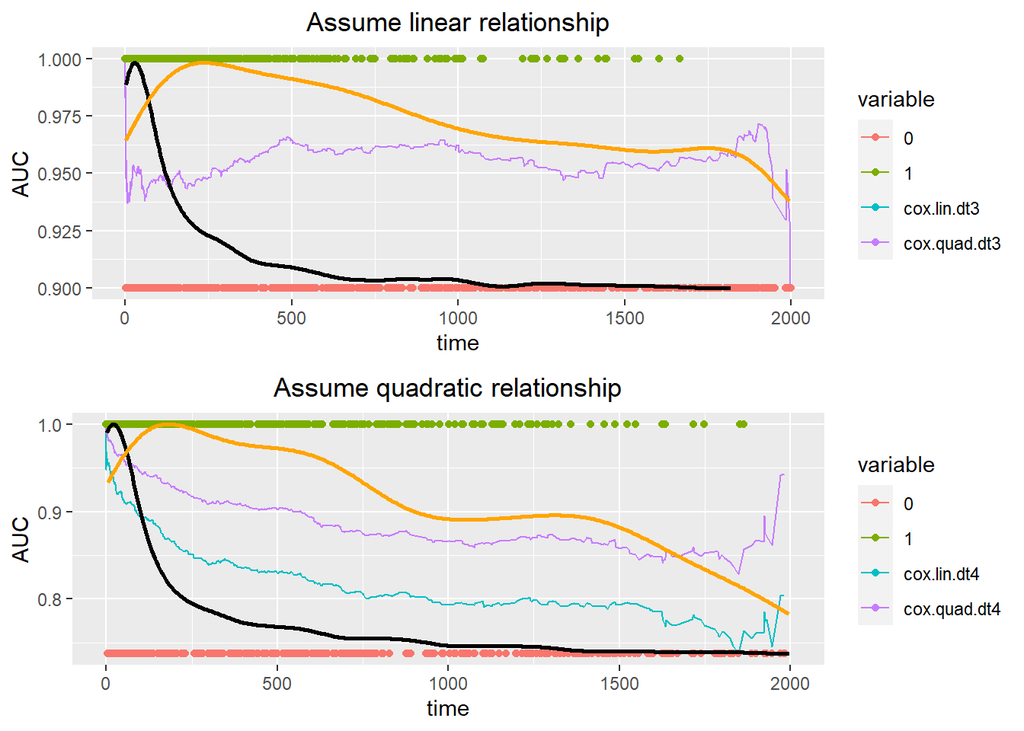

```r
a <- ggplot()

fig1 <- a +
  geom_line(data=res3, aes(x=time, y=value,
                            group=variable, color=variable)) +
  geom_point(data=dt3, aes(x=time, y=censor1, color=as.factor(censor))) +
  geom_line(data=data3_1, aes(x=time, y=density.adjusted),
            size=1, colour='black') +
  geom_line(data=data3_2, aes(x=time, y=density.adjusted),
            size=1, colour='orange') +
  scale_x_continuous(limits = c(0, 2000)) +
  ggtitle("Assume linear relationship") +
  xlab("time") + ylab("AUC") +
  theme(plot.title = element_text(hjust = 0.5))

fig2 <- a +
  geom_line(data=res4, aes(x=time, y=value,
                            group=variable, color=variable)) +
  geom_point(data=dt4, aes(x=time, y=censor1, color=as.factor(censor))) +
  geom_line(data=data4_1, aes(x=time, y=density.adjusted),
            size=1, colour='black') +
  geom_line(data=data4_2, aes(x=time, y=density.adjusted),
            size=1, colour='orange') +
  scale_x_continuous(limits = c(0, 2000)) +
  ggtitle("Assume quadratic relationship") +
  xlab("time") + ylab("AUC") +
  theme(plot.title = element_text(hjust = 0.5))

grid.arrange(fig1, fig2, nrow=2, ncol=1)
```

### Assume linear relationship

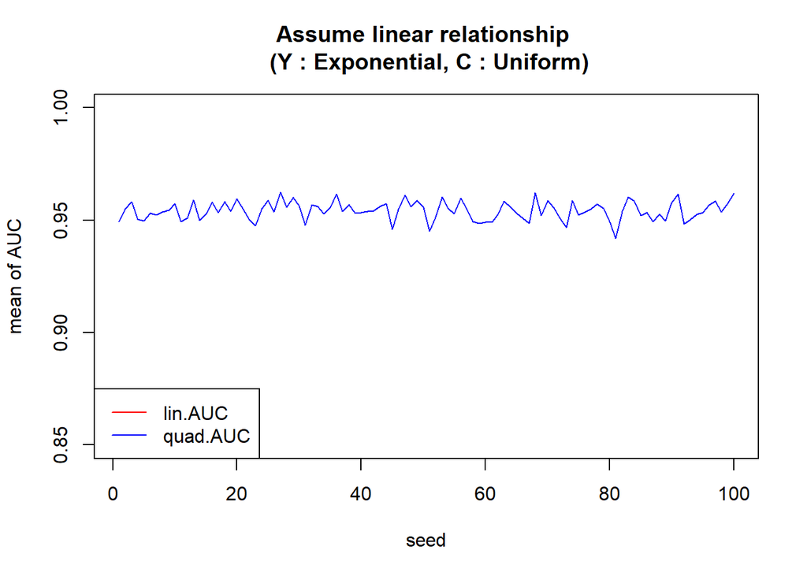

```r
seed <- c()
lin.AUC <- c()
quad.AUC <- c()

for (i in 1:100) {

  # Assume parametric basis distribution is Exponential distribution...
  lambda1 <- 0.001 # parameter for generate Y
  lambda2 <- 2/lambda1 # parameter for generate C
  beta1 <- 3 # true coefficients
  Y <- c() # real survival time
  C <- c() # censoring time
  t <- c() # observed survival time
  censor <- c() # censoring indicator
  X <- c() # explanatory variable
  U1 <- c() # random variable from U(0,1) for generate Y
  U2 <- c() # random variable from U(0,1) for generate C
  X2 <- c() # X^2

  # Generate simulation data (Assume linear relationship)
  seed[i] <- i
  set.seed(i)
  for (j in 1:1000) {
    U1[j] <- runif(1)
    U2[j] <- runif(1)
    X[j] <- rnorm(1,mean=0,sd=1)
    X2[j] <- X[j]^2
    Y[j] <- -(1/lambda1)*log(U1[j])*exp(-beta1*X[j])
    C[j] <- (lambda2)*(1-U2[j])
    t[j] <- min(Y[j],C[j])
    censor[j] <- ifelse(Y[j]<=C[j],1,0)
  }
  dt3 <- data.frame(X=X, X2=X2, Y=Y, C=C, time=t, censor=censor)

  # Set linear model
  cox.lin.dt3 <- coxph(Surv(time,censor) ~ X, data=dt3)
  risk.lin.dt3 <- predict(object=cox.lin.dt3, newdata=dt3, type="risk")
  dt3$risk.lin.dt3 <- risk.lin.dt3
  ROC.risk.lin.dt3 <- timeROC(T=dt3$time,
                         delta=dt3$censor,marker=dt3$risk.lin.dt3,
                         cause=1,weighting="marginal",
                         times=dt3$time)

  # Set quadratic model
  cox.quad.dt3 <- coxph(Surv(time,censor) ~ X+X2, data=dt3)
  risk.quad.dt3 <- predict(object=cox.quad.dt3, newdata=dt3, type="risk")
  dt3$risk.quad.dt3 <- risk.quad.dt3
  ROC.risk.quad.dt3 <- timeROC(T=dt3$time,
                         delta=dt3$censor,marker=dt3$risk.quad.dt3,
                         cause=1,weighting="marginal",
                         times=dt3$time)

  # Calculate mean value of time dependent AUC
  lin.AUC[i] <- mean(ROC.risk.lin.dt3[["AUC"]],na.rm=TRUE)
  quad.AUC[i] <- mean(ROC.risk.quad.dt3[["AUC"]],na.rm=TRUE)

  # print(i)

}

dat3 <- data.frame(seed=seed, lin.AUC=lin.AUC, quad.AUC=quad.AUC)
plot(x=dat3$seed, y=dat3$lin.AUC, xlab="seed", ylab="mean of AUC",
     main="Assume linear relationship \n (Y : Exponential, C : Uniform)", type="l", col="red", ylim=c(0.85,1))
lines(x=dat3$seed, y=dat3$quad.AUC, type="l", col="blue")
legend("bottomleft",c("lin.AUC","quad.AUC"),col=c("red","blue"),lty=c(1,1))
```

### Assume quadratic relationship

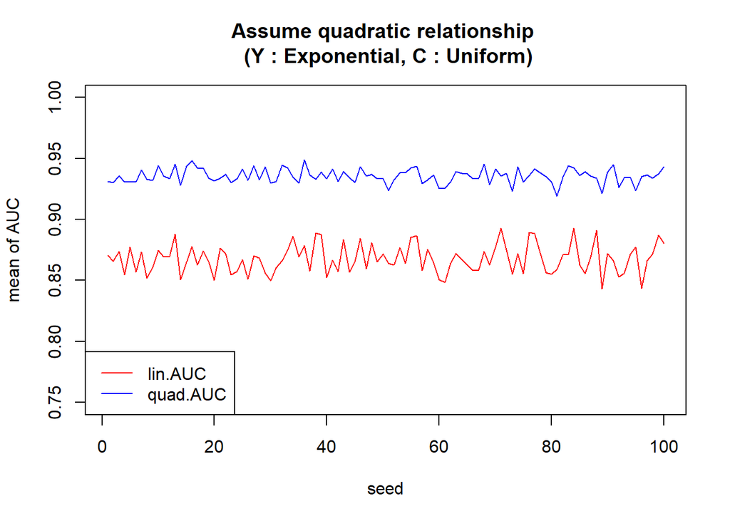

```r
seed <- c()
lin.AUC <- c()
quad.AUC <- c()

for (i in 1:100) {

  # Assume parametric basis distribution is Exponential distribution...
  lambda1 <- 0.001 # parameter for generate Y
  lambda2 <- 2/lambda1 # parameter for generate C
  beta1 <- 3 ; beta2 <- 2 # true coefficients
  Y <- c() # real survival time
  C <- c() # censoring time
  t <- c() # observed survival time
  censor <- c() # censoring indicator
  X <- c() # explanatory variable
  U1 <- c() # random variable from U(0,1) for generate Y
  U2 <- c() # random variable from U(0,1) for generate C
  X2 <- c() # X^2

  # Generate simulation data (Assume quadratic relationship)
  seed[i] <- i
  set.seed(i)
  for (j in 1:1000) {
    U1[j] <- runif(1)
    U2[j] <- runif(1)
    X[j] <- rnorm(1,mean=0,sd=1)
    X2[j] <- X[j]^2
    Y[j] <- -(1/lambda1)*log(U1[j])*exp(-beta1*X[j]-beta2*X2[j])
    C[j] <- (lambda2)*(1-U2[j])
    t[j] <- min(Y[j],C[j])
    censor[j] <- ifelse(Y[j]<=C[j],1,0)
  }
  dt4 <- data.frame(X=X, X2=X2, Y=Y, C=C, time=t, censor=censor)

  # Set linear model
  cox.lin.dt4 <- coxph(Surv(time,censor) ~ X, data=dt4)
  risk.lin.dt4 <- predict(object=cox.lin.dt4, newdata=dt4, type="risk")
  dt4$risk.lin.dt4 <- risk.lin.dt4
  ROC.risk.lin.dt4 <- timeROC(T=dt4$time,
                         delta=dt4$censor,marker=dt4$risk.lin.dt4,
                         cause=1,weighting="marginal",
                         times=dt4$time)

  # Set quadratic model
  cox.quad.dt4 <- coxph(Surv(time,censor) ~ X+X2, data=dt4)
  risk.quad.dt4 <- predict(object=cox.quad.dt4, newdata=dt4, type="risk")
  dt4$risk.quad.dt4 <- risk.quad.dt4
  ROC.risk.quad.dt4 <- timeROC(T=dt4$time,
                         delta=dt4$censor,marker=dt4$risk.quad.dt4,
                         cause=1,weighting="marginal",
                         times=dt4$time)

  # Calculate mean value of time dependent AUC
  lin.AUC[i] <- mean(ROC.risk.lin.dt4[["AUC"]],na.rm=TRUE)
  quad.AUC[i] <- mean(ROC.risk.quad.dt4[["AUC"]],na.rm=TRUE)

  # print(i)

}

dat4 <- data.frame(seed=seed, lin.AUC=lin.AUC, quad.AUC=quad.AUC)
plot(x=dat4$seed, y=dat4$lin.AUC, xlab="seed", ylab="mean of AUC",
     main="Assume quadratic relationship \n (Y : Exponential, C : Uniform)", type="l", col="red", ylim=c(0.75,1))
lines(x=dat4$seed, y=dat4$quad.AUC, type="l", col="blue")
legend("bottomleft",c("lin.AUC","quad.AUC"),col=c("red","blue"),lty=c(1,1))
```